← 8. Engagement (optional)indexstudent version10. Multiple comparisons (Part 2) →

# Notebook 9 — Individual differences

*SWC ENC 2026 · behaviour module · Part 2 (population-level inference)*

This is the first of three notebooks on **inference across a population**. They're modular — each stands alone, and any section can be skipped and left for self-study.

Here we reproduce **Figure 2H**: mice have their own strategy *preferences*, stable across sessions. Two questions, two tools:

- *How much* of the variation in strategy is between mice vs. within a mouse? → **variance partitioning**.
- Is that more than you'd expect by chance? → a **permutation test**.

Both hinge on the fact that our data are **nested** — several sessions per mouse — which is the theme of this whole part.

**The paper panel this notebook reproduces**

[figure not shown]

*Fig. 2H — each mouse's sessions (dots) sorted by the mouse's average strategy index; the spread within a column is within-mouse, the trend across columns is between-mouse. Mouse identity explained ~72% of the variance, vs ~22% when the labels were shuffled.*

## Setup

We generate a **cohort**: several sessions from each of many mice, where every mouse has its own *stable* strategy plus session-to-session wobble. For each session we fit the static model (Notebook 3) and summarize its strategy by a single fast number, the recovered **visual − timing** weight. This cell always runs; the sections after it are independent. *(Fitting the cohort takes ~5 s.)*

```python
import numpy as np
import matplotlib.pyplot as plt
import swcbehav as sb

cohort = sb.make_cohort(n_mice=12, sessions_per_mouse=4, seed=1)

def session_strategy(cs):
    X, cols = sb.build_design_matrix(cs.session.table)
    y = cs.session.table["bout_start"].to_numpy().astype(float)
    w = sb.fit_static(X, y)
    return w[1] - w[4]                 # visual weight minus timing weight

strategy = np.array([session_strategy(cs) for cs in cohort])
mouse = np.array([cs.mouse_id for cs in cohort])
print(f"{len(cohort)} sessions from {mouse.max() + 1} mice")
```

```
48 sessions from 12 mice
```

## 1. Look at the data

Sort the mice by their average strategy and plot every session, colored by mouse. Sessions from the same mouse cluster together (a short vertical spread), while the mouse averages march steadily across — the visual signature of a trait that is more between-mouse than within-mouse. This is our Figure 2H.

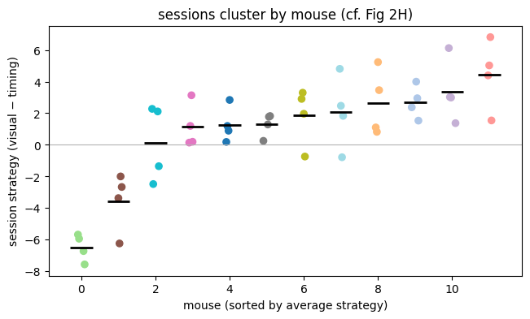

```python
means = np.array([strategy[mouse == m].mean() for m in np.unique(mouse)])
order = np.unique(mouse)[np.argsort(means)]
xpos = np.array([list(order).index(m) for m in mouse])
jitter = (np.arange(len(mouse)) % 7 - 3) * 0.03      # spread sessions within a column

plt.figure(figsize=(7.5, 4))
plt.scatter(xpos + jitter, strategy, c=mouse, cmap="tab20", s=35)
for i, m in enumerate(order):
    plt.hlines(strategy[mouse == m].mean(), i - 0.3, i + 0.3, color="k", lw=2)
plt.axhline(0, color="0.7", lw=0.8)
plt.xlabel("mouse (sorted by average strategy)")
plt.ylabel("session strategy (visual − timing)")
plt.title("sessions cluster by mouse (cf. Fig 2H)")
plt.show()
```

## 2. Variance partitioning

We can make "clusters by mouse" quantitative. Split the total spread of the session values into a part **between** mice (how far each mouse's average sits from the grand average) and the rest **within** mice, and report the between-mouse share:

$$\text{variance explained by mouse} \;=\; \frac{\sum_m n_m\,(\bar{x}_m - \bar{x})^2}{\sum_i (x_i - \bar{x})^2} \;=\; \frac{\text{between-mouse sum of squares}}{\text{total sum of squares}}.$$

It runs from 0 (all mice identical on average) to 1 (no within-mouse spread at all). This quantity is $\eta^2$ — the same thing a one-way ANOVA reports.

**Exercise 1** *(~6 min)*. Complete `variance_explained`.

> **Check / unstuck.** Expect **≈ 0.79** (matches `sb.variance_explained`). Stuck? Use `sb.variance_explained(strategy, mouse)`.

```python
def variance_explained(values, groups):
    values, groups = np.asarray(values, float), np.asarray(groups)
    grand = values.mean()
    ss_total = np.sum((values - grand) ** 2)
    ss_between = sum(len(values[groups == g]) * (values[groups == g].mean() - grand) ** 2
                     for g in np.unique(groups))
    return ss_between / ss_total

observed = variance_explained(strategy, mouse)
print(f"variance explained by mouse identity: {observed:.2f}")
print("backend check:", round(sb.variance_explained(strategy, mouse), 2))
```

```
variance explained by mouse identity: 0.79
backend check: 0.79
```

## 3. Is it more than chance? A permutation test

A number like 0.8 *sounds* big, but we need a null: how much variance would mouse identity "explain" if the labels were **meaningless**? A **permutation test** answers this without any distributional assumptions. The recipe:

1. Compute the statistic on the real data (done above).
2. **Shuffle** the mouse labels — destroying any real link between session and mouse — and recompute the statistic. Repeat many times to trace out the null distribution: *what the statistic looks like when the structure is fake*.
3. The p-value is the fraction of shuffles that match or beat the real value.

**Exercise 2** *(~6 min)*. Complete `permutation_test`. Use `sb.variance_explained` as the statistic (so this section works even if you skipped Exercise 1).

> **Check / unstuck.** Expect **observed ≈ 0.79, shuffled ≈ 0.23, p ≈ 0.0005**. Stuck? Use `sb.permutation_variance_explained(strategy, mouse)`.

```python
def permutation_test(values, groups, n_perm=2000, seed=0):
    rng = np.random.default_rng(seed)
    observed = sb.variance_explained(values, groups)
    null = np.array([sb.variance_explained(values, rng.permutation(groups))
                     for _ in range(n_perm)])
    p = (np.sum(null >= observed) + 1) / (n_perm + 1)
    return observed, null, p

observed, null, p = permutation_test(strategy, mouse)
print(f"observed = {observed:.2f},  shuffled mean = {null.mean():.2f},  p = {p:.4f}")
```

```
observed = 0.79,  shuffled mean = 0.23,  p = 0.0005
```

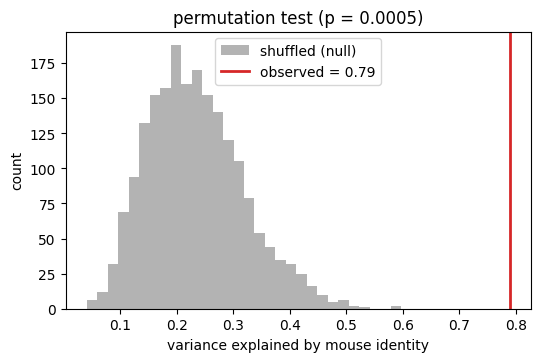

```python
plt.figure(figsize=(6, 3.6))
plt.hist(null, bins=30, color="0.7", label="shuffled (null)")
plt.axvline(observed, color="tab:red", lw=2, label=f"observed = {observed:.2f}")
plt.xlabel("variance explained by mouse identity"); plt.ylabel("count")
plt.title(f"permutation test (p = {p:.4f})"); plt.legend()
plt.show()
```

The observed value sits far out in the tail of the null, so mouse identity explains much more than chance — strategy is a **stable individual trait**, just as in the paper. Note where the null piles up: with $k$ mice and $N$ sessions, shuffled labels explain about $(k-1)/(N-1)$ of the variance on average — here $11/47 \approx 0.23$, matching the paper's ~22%. That's the baseline any real effect must clear.

## 4. (Optional) Check against the ground truth

*Skippable.* Because we built the cohort, we know each session's **true** strategy tilt and each mouse's stable latent. Partitioning the *true* tilts tells us how much structure is really there, and we can confirm the value we recovered from noisy model fits lands in the same place.

```python
true_tilt = np.array([cs.session_tilt for cs in cohort])
print("variance explained using TRUE tilts     :", round(sb.variance_explained(true_tilt, mouse), 2))
print("variance explained using RECOVERED fits  :", round(sb.variance_explained(strategy, mouse), 2))
print("(close -> the fit recovered the individual structure, not just noise)")
```

```
variance explained using TRUE tilts     : 0.8
variance explained using RECOVERED fits  : 0.79
(close -> the fit recovered the individual structure, not just noise)
```

## Wrap-up

You quantified individual differences with variance partitioning and tested them with a permutation test — a general, assumption-light tool you'll reach for constantly. The key structural fact was that sessions are **nested within mice**. The next two notebooks take that nesting seriously:

- **Notebook 10** — when you run *many* tests (one per strategy, say), how to keep false positives under control.
- **Notebook 11** — how to put honest error bars on a nested-data average with the hierarchical bootstrap.

← 8. Engagement (optional)indexstudent version10. Multiple comparisons (Part 2) →